# Time Series Analysis NYC Births & Air Quality

Elizabeth Van Der Schaaf

2024-11-22

# Introduction

The typical goal of time series analysis is to use data points gathered at regular intervals to predict future values. Methods such as decomposition can be used to determine the underlying structure of the data. Single moving average or exponential smoothing can help reduce noise. ARIMA is a popular model for time series analysis which incorporates autoregression, differencing, and moving average.

This report will decompose time series data concerning births in NYC from 1946 - 1959. Then another dataset concerning the presence of volcanic ash in the northern hemisphere will be analyzed. An ARIMA model will be fit and used to forecast. These forecasted values will be evaluated against known values.

# Analysis

## Task 1

**Decompose the seasonal time series data and subtract that effect from the NYC births data set**

First load the data and create a time series object.

```r
# Read in data
births <- scan("http://robjhyndman.com/tsdldata/data/nybirths.dat")
str(births)
```

```
##  num [1:168] 26.7 23.6 26.9 24.7 25.8 ...
```

```r
# Create time series object
birthstimeseries <- ts(births, frequency=12, start=c(1946,1))
print(birthstimeseries)
```

```
##         Jan    Feb    Mar    Apr    May    Jun    Jul    Aug    Sep    Oct
## 1946 26.663 23.598 26.931 24.740 25.806 24.364 24.477 23.901 23.175 23.227
## 1947 21.439 21.089 23.709 21.669 21.752 20.761 23.479 23.824 23.105 23.110
## 1948 21.937 20.035 23.590 21.672 22.222 22.123 23.950 23.504 22.238 23.142
## 1949 21.548 20.000 22.424 20.615 21.761 22.874 24.104 23.748 23.262 22.907
## 1950 22.604 20.894 24.677 23.673 25.320 23.583 24.671 24.454 24.122 24.252
## 1951 23.287 23.049 25.076 24.037 24.430 24.667 26.451 25.618 25.014 25.110
## 1952 23.798 22.270 24.775 22.646 23.988 24.737 26.276 25.816 25.210 25.199
## 1953 24.364 22.644 25.565 24.062 25.431 24.635 27.009 26.606 26.268 26.462
## 1954 24.657 23.304 26.982 26.199 27.210 26.122 26.706 26.878 26.152 26.379
## 1955 24.990 24.239 26.721 23.475 24.767 26.219 28.361 28.599 27.914 27.784
## 1956 26.217 24.218 27.914 26.975 28.527 27.139 28.982 28.169 28.056 29.136
## 1957 26.589 24.848 27.543 26.896 28.878 27.390 28.065 28.141 29.048 28.484
## 1958 27.132 24.924 28.963 26.589 27.931 28.009 29.229 28.759 28.405 27.945
## 1959 26.076 25.286 27.660 25.951 26.398 25.565 28.865 30.000 29.261 29.012
##         Nov    Dec
## 1946 21.672 21.870
## 1947 21.759 22.073
## 1948 21.059 21.573
## 1949 21.519 22.025
## 1950 22.084 22.991
## 1951 22.964 23.981
## 1952 23.162 24.707
## 1953 25.246 25.180
## 1954 24.712 25.688
## 1955 25.693 26.881
## 1956 26.291 26.987
## 1957 26.634 27.735
## 1958 25.912 26.619
## 1959 26.992 27.897
```

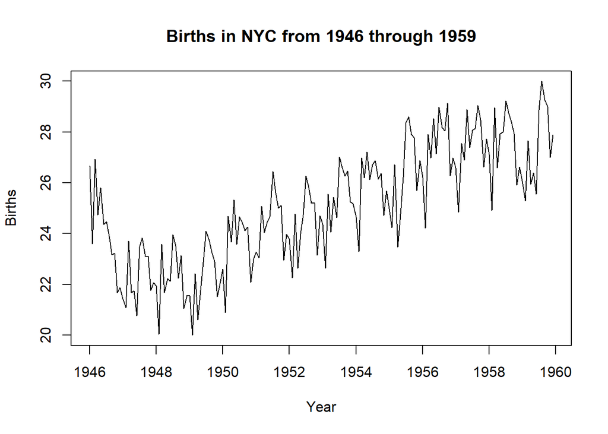

**Figure 1.** Time series plot of NYC births

```r
# Plot the data
plot.ts(birthstimeseries, main='Births in NYC from 1946 through 1959', xlab='Year', ylab='Births')
```

The data appears to have a trend as well as seasonality. The variation looks about even, indicating an additive model would be appropriate.

Decompose the data into seasonal, trend, and random parts.

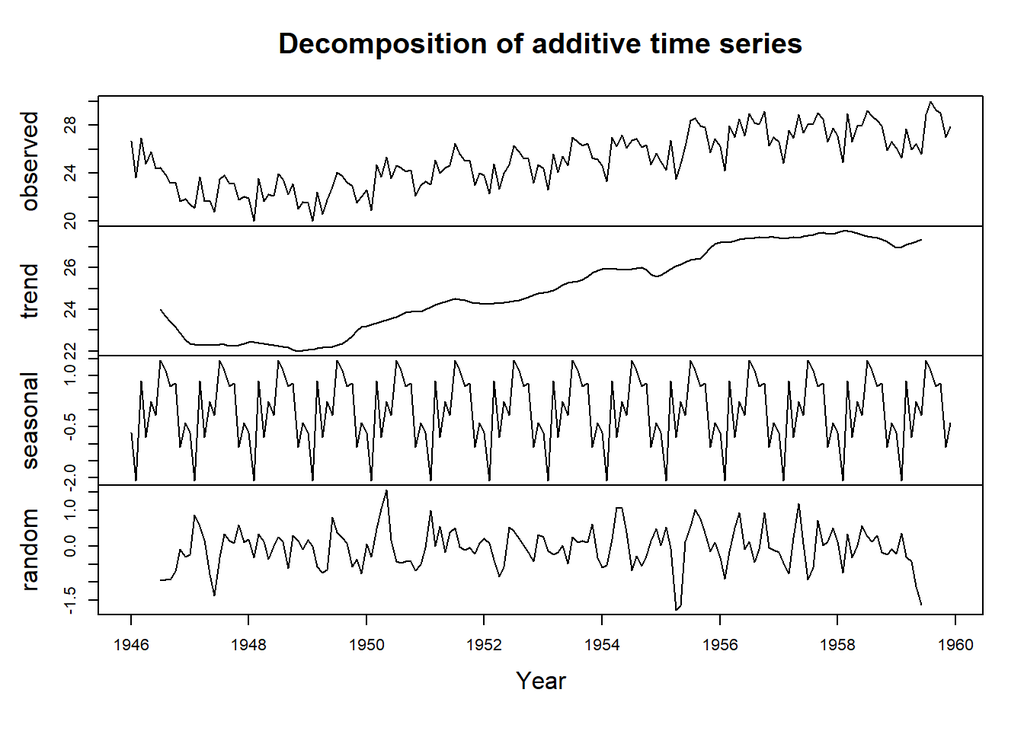

**Figure 2.** Decomposition of NYC births time series data

```r
births_components <- decompose(birthstimeseries)
plot(births_components, xlab='Year')
```

Next, subtract only the seasonal component from the original data.

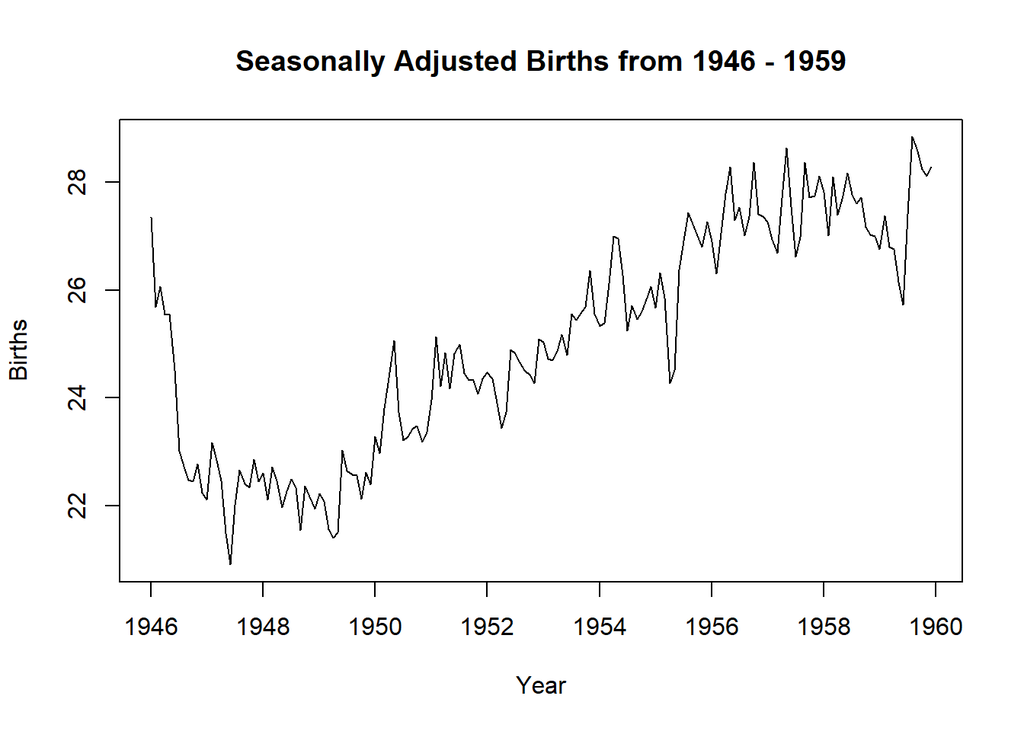

**Figure 3.** Time series plot of seasonally adjusted NYC births data

```r
seasonally_adj_births <- birthstimeseries - births_components$seasonal
plot(seasonally_adj_births, main='Seasonally Adjusted Births from 1946 - 1959', xlab='Year', ylab='Births')
```

## Task 2

**Address correlations between successive time series values in the atmospheric volcano dust data set. Use ARIMA models for this irregular component of a time series.**

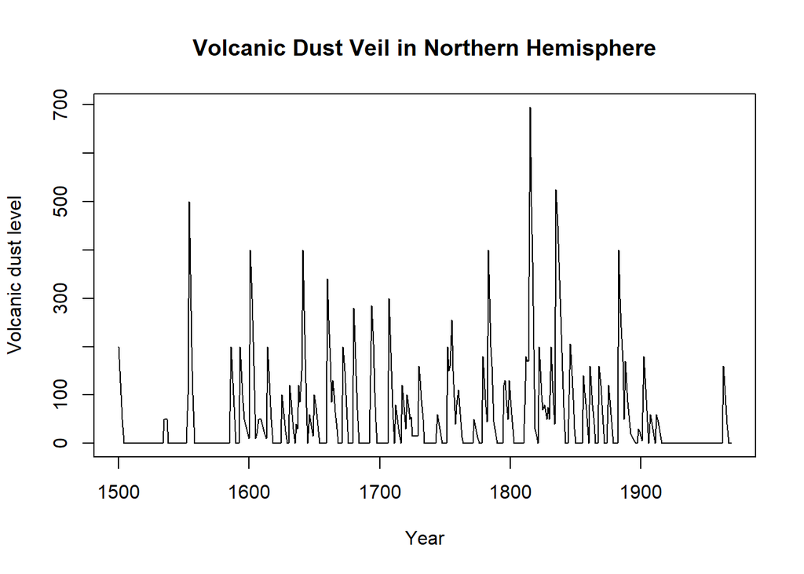

**Figure 4.** Northern hemisphere volcanic dust veil time series data

```r
# Load data
volcanodust <- scan("http://robjhyndman.com/tsdldata/annual/dvi.dat", skip=1)
# Create time series object
START = 1500
volcanodustseries <- ts(volcanodust,start=c(START))
plot.ts(volcanodustseries, main='Volcanic Dust Veil in Northern Hemisphere', xlab='Year', ylab='Volcanic dust level')
```

This data does not appear to have a trend or seasonality and variance is roughly constant. We can run an augmented Dickey-Fuller test to be sure.

```r
adf <- adf.test(volcanodust)
print(adf)
```

```
##
##  Augmented Dickey-Fuller Test
##
## data:  volcanodust
## Dickey-Fuller = -6.518, Lag order = 7, p-value = 0.01
## alternative hypothesis: stationary
```

The test confirms that the data is stationary. It is therefore appropriate to fit an ARIMA model directly, without differencing.

The next step is plotting the Auto Correlation Function to determine the most important lags (20 will be our maximum lag).

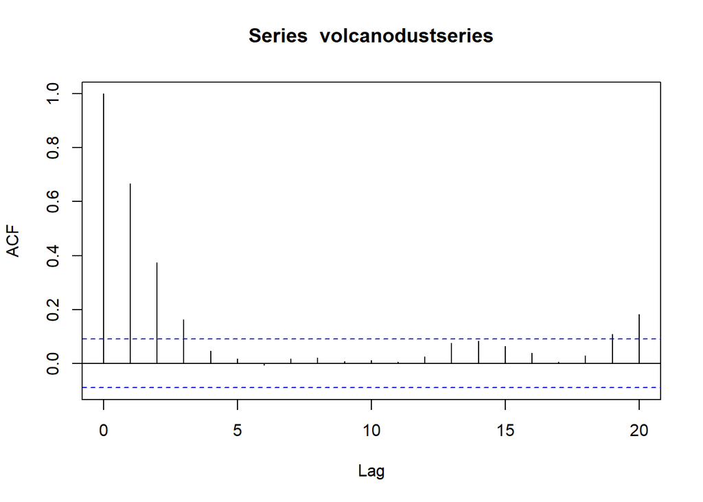

**Figure 5.** Auto correlation function plot for volcanic dust data

```r
acf(volcanodustseries, lag.max=20)
```

```r
# Get values of autocorrelations
print(acf(volcanodustseries, lag.max=20, plot=FALSE))
```

```
##
## Autocorrelations of series 'volcanodustseries', by lag
##
##      0      1      2      3      4      5      6      7      8      9     10
##  1.000  0.666  0.374  0.162  0.046  0.017 -0.007  0.016  0.021  0.006  0.010
##     11     12     13     14     15     16     17     18     19     20
##  0.004  0.024  0.075  0.082  0.064  0.039  0.005  0.028  0.108  0.182
```

The values tend towards zero after lag 3, indicating q = 3 might be a good choice for an ARIMA model.

```r
arima_1 <- arima(volcanodust, order = c(0, 0, 3))
summary(arima_1)
```

```
##
## Call:
## arima(x = volcanodust, order = c(0, 0, 3))
##
## Coefficients:
##          ma1     ma2     ma3  intercept
##       0.7438  0.4513  0.1916    57.4559
## s.e.  0.0455  0.0502  0.0442     7.6534
##
## sigma^2 estimated as 4852:  log likelihood = -2661.69,  aic = 5333.39
##
## Training set error measures:
##                      ME     RMSE     MAE  MPE MAPE      MASE       ACF1
## Training set -0.1739973 69.65537 37.9891 -Inf  Inf 0.9959132 0.00407383
```

Next, examine the partial autocorrelation function to determine an appropriate value for p.

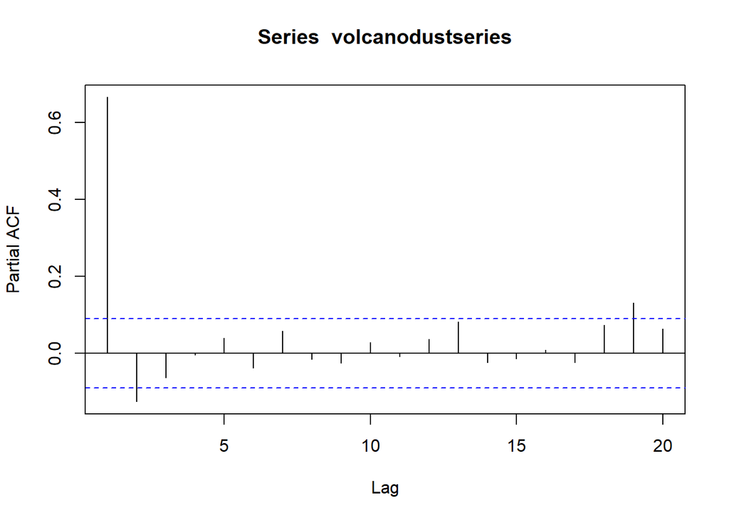

**Figure 6.** Partial auto correlation function plot for volcanic dust data

```r
pacf(volcanodustseries, lag.max=20)
```

```r
# Get values of partial autocorrelations
print(pacf(volcanodustseries, lag.max=20, plot=FALSE))
```

```
##
## Partial autocorrelations of series 'volcanodustseries', by lag
##
##      1      2      3      4      5      6      7      8      9     10     11
##  0.666 -0.126 -0.064 -0.005  0.040 -0.039  0.058 -0.016 -0.025  0.028 -0.008
##     12     13     14     15     16     17     18     19     20
##  0.036  0.082 -0.025 -0.014  0.008 -0.025  0.073  0.131  0.063
```

The partial autocorrelation values tend towards zero after lag 2, indicating p = 2 might be a good choice.

```r
arima_2 <- arima(volcanodust, order = c(2, 0, 0))
summary(arima_2)
```

```
##
## Call:
## arima(x = volcanodust, order = c(2, 0, 0))
##
## Coefficients:
##          ar1      ar2  intercept
##       0.7533  -0.1268    57.5274
## s.e.  0.0457   0.0458     8.5958
##
## sigma^2 estimated as 4870:  log likelihood = -2662.54,  aic = 5333.09
##
## Training set error measures:
##                      ME     RMSE      MAE  MPE MAPE      MASE        ACF1
## Training set -0.2205417 69.78253 37.86389 -Inf  Inf 0.9926308 -0.00982403
```

We can use *auto.arima()* to help determine an appropriate model.

```r
auto_arima <- auto.arima(volcanodust)
summary(auto_arima)
```

```
## Series: volcanodust
## ARIMA(1,0,2) with non-zero mean
##
## Coefficients:
##          ar1     ma1     ma2     mean
##       0.4723  0.2694  0.1279  57.5178
## s.e.  0.0936  0.0969  0.0752   8.4883
##
## sigma^2 = 4897:  log likelihood = -2661.84
## AIC=5333.68   AICc=5333.81   BIC=5354.45
##
## Training set error measures:
##                      ME     RMSE      MAE  MPE MAPE      MASE        ACF1
## Training set -0.2117223 69.67759 37.71798 -Inf  Inf 0.9888057 0.001099883
```

The *auto.arima()* function indicates a model with p = 1 and q = 2 is optimal. Let’s compare the AIC scores.

```r
aic_table <- data.frame(
  Model = c("ARIMA(0,0,3)", "ARIMA(2,0,0)", "ARIMA(1,0,2)"),
  AIC = c(arima_1$aic, arima_2$aic, auto_arima$aic)
)
aic_table |>
  arrange(AIC) |>
  flextable() |>
  set_table_properties(width = .3, layout = "autofit")
```

| Model | AIC |
| --- | --- |
| ARIMA(2,0,0) | 5,333.088 |
| ARIMA(0,0,3) | 5,333.388 |
| ARIMA(1,0,2) | 5,333.682 |

**Table 1.** AIC values for ARIMA models using volcano dust data.

Based on the AIC values, the ARIMA(2,0,0) model is the best. It is also the model with the fewest parameters.

We can proceed to evaluate this model by making predictions against the supplied dataset.

Split data into train and test sets, keeping the last 10 data points for testing.

```r
# Total number of observations
num <- length(volcanodustseries)
# Split into train and test
train <- volcanodustseries[1:(num - 10)]
test <- volcanodustseries[(num - 9):num]
print(paste("Number of observations in train set:", {length(train)}))
```

```
## [1] "Number of observations in train set: 460"
```

```r
print(paste("Number of observations in test set:", {length(test)}))
```

```
## [1] "Number of observations in test set: 10"
```

Now to fit the model.

```r
# Create time series object
train_ts <- ts(train,start=c(START))
test_ts <- ts(test, start=c(START+length(train)))
# Fit model
arima200 <- arima(train, order=c(2,0,0))
summary(arima200)
```

```
##
## Call:
## arima(x = train, order = c(2, 0, 0))
##
## Coefficients:
##          ar1      ar2  intercept
##       0.7539  -0.1259    57.9077
## s.e.  0.0462   0.0463     8.7692
##
## sigma^2 estimated as 4922:  log likelihood = -2608.39,  aic = 5224.77
##
## Training set error measures:
##                      ME     RMSE      MAE  MPE MAPE      MASE         ACF1
## Training set -0.2255978 70.16037 38.02534 -Inf  Inf 0.9933769 -0.009600484
```

This model can be expressed as:

$$y_t = 57.9077 + 0.7539 y_{t-1} - 0.1259 y_{t-2} + \epsilon_t$$
This is an AR model of order 2 (2 lagged values are used as predictors).

```r
predictions <- forecast(arima200, h=10)
print(predictions)
```

```
##     Point Forecast     Lo 80    Hi 80     Lo 95    Hi 95
## 461       21.53895 -68.37518 111.4531 -115.9729 159.0508
## 462       37.77813 -74.82771 150.3840 -134.4376 209.9939
## 463       47.30987 -72.11931 166.7390 -135.3413 229.9610
## 464       52.45179 -68.89100 173.7946 -133.1260 238.0296
## 465       55.12849 -66.72768 176.9847 -131.2344 241.4914
## 466       56.49921 -65.49123 178.4897 -130.0691 243.0675
## 467       57.19567 -64.82941 179.2208 -129.4256 243.8169
## 468       57.54820 -64.48576 179.5822 -129.0866 244.1830
## 469       57.72629 -64.30993 179.7625 -128.9120 244.3646
## 470       57.81619 -64.22061 179.8530 -128.8230 244.4554
```

Visualize the predictions.

```r
# Extract mean predictions
pred_mean <- predictions$mean
# Create time series object
pred_ts <- ts(pred_mean, start=c(START+length(train)))
```

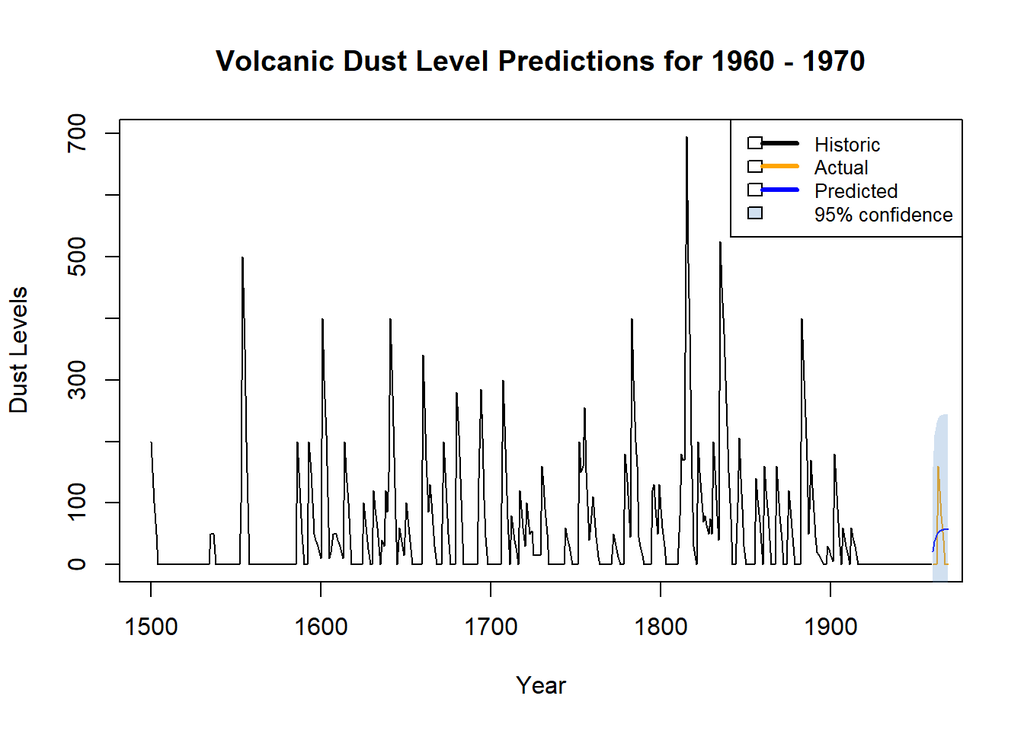

**Figure 7.** Volcanic dust levels with forecast levels for 1960 - 1970, including a 95% confidence interval, using ARIMA(2,0,0) model.

```r
# Plot historic data
plot(train_ts, type='l', col='black', xlab='Year', ylab='Dust Levels',
     main='Volcanic Dust Level Predictions for 1960 - 1970')

# Add reference data
lines(test_ts, col='orange')

# Add predictions
lines(pred_ts, col='blue')

# Add confidence interval
polygon(c(time(pred_ts), rev(time(pred_ts))),
        c(predictions$lower[,2], rev(predictions$upper[,2])),
        col=rgb(0.4, 0.6, 0.8, alpha=0.3), border=NA)

# Legend
legend("topright", legend=c("Historic", "Actual", "Predicted", "95% confidence"),
       col=c("black", "orange", "blue", "lightblue"), lty=1, lwd=c(3, 3, 3, NA),
       fill=c(NA, NA, NA, rgb(0.4, 0.6, 0.8, alpha=0.3)), cex=0.8)
```

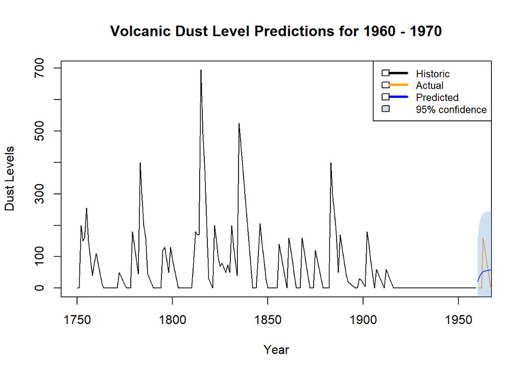

**Figure 8.** A closer look at predictions of ARIMA(2,0,0)

```r
# Truncate historic data
train_ts_subset <- window(train_ts, start=c(1750))

# New plot
plot(train_ts_subset, type='l', col='black', xlab='Year', ylab='Dust Levels',
     main='Volcanic Dust Level Predictions for 1960 - 1970')

lines(test_ts, col='orange')
lines(pred_ts, col='blue')

polygon(c(time(pred_ts), rev(time(pred_ts))),
        c(predictions$lower[,2], rev(predictions$upper[,2])),
        col=rgb(0.4, 0.6, 0.8, alpha=0.3), border=NA)

legend("topright", legend=c("Historic", "Actual", "Predicted", "95% confidence"),
       col=c("black", "orange", "blue", "lightblue"), lty=1, lwd=c(3, 3, 3, NA),
       fill=c(NA, NA, NA, rgb(0.4, 0.6, 0.8, alpha=0.3)), cex=0.8)
```

Determine the Mean Absolute Deviation of the model.

```r
mad <- mean(abs(test_ts - pred_ts))
cat("MAD score for ARIMA(2,0,0):", mad)
```

```
## MAD score for ARIMA(2,0,0): 49.28338
```

```r
error_margin <- (mad/max(volcanodust)*100)
cat("Margin of error for this model is", round(error_margin, 3), "%")
```

```
## Margin of error for this model is 7.091 %
```

# Conclusion

The optimal model for forecasting volcanic ash levels in the northern hemisphere, as determined by AIC scores, is the ARIMA(2,0,0) model which uses 2 lag values as predictors. Comparing forecast values to actual values for the most recent 10 years of data gives a MAD of 49.28. This corresponds to a 7.09% margin of error. As seen in Figures 7 and 8, the actual values do fall within the 95% confidence interval for the predictions.

I’m not very familiar with the domain of volcanic ash levels, but a 7.09% margin of error seems reasonable. The model did forecast slightly elevated levels of volcanic ash after a few decades of near zero levels, which does correspond with the actual data for this period.

# References

Coghlan, A. (2018, September 10). *Using R for Time Series Analysis.* https://a-little-book-of-r-for-time-series.readthedocs.io/en/latest/src/timeseries.html